# HW6

## Assignment 6

## Task 1

Anaconda Prompt

- Creating a new environment named geo_env
- Install geopandas

```python
#Creating a new environment named geo_env or other names
#activate geo_env
    #Anaconda prompt: conda activate geo_env
#activate geo_env kernel in vscode

import geopandas
```

## Task 2

- Find at least three sets of spatial data, in Shapefile, zipped Shapefile, GeoJSON, or other supported formats. If you have well-prepared data from previous works, you can also use them. You can use the three zipped files in the Code folder on Dropbox, which are the new electoral district maps in NYS.
- Import those data into GeoDataFrame using geopandas. Take one dataset as an example, show the specific types of the entire dataframe, the geometry column, and individual geometry object. This also helps you get familiar with pandas subsetting (choose rows and columns from the tabular data).
- Export all three into a SINGLE geopackage file (geodatabase). Note that the single geopackage file should have three layers inside, not three layers in three separate geopackage files.

Import Data

```python
#import data using geopandas
sen22 = geopandas.read_file('./SEN22_June_03_2022.zip', driver = 'zip')
con22 = geopandas.read_file('./CON22_June_03_2022.zip', driver = 'zip')
ably22 = geopandas.read_file('./2022assembly_shape_file.zip', driver = 'zip')
```

Specific Types

```python
#inspect sen22
sen22.head(8)
```

|  | OBJECTID | Shape_Leng | Shape_Area | District | geometry |
| --- | --- | --- | --- | --- | --- |
| 0 | 1 | 322853.258786 | 3.954679e+09 | 1 | POLYGON ((742169.526 4532898.369, 736334.250 4... |
| 1 | 2 | 114388.392696 | 6.435845e+08 | 2 | POLYGON ((655759.831 4532072.892, 655703.520 4... |
| 2 | 3 | 160278.163328 | 8.341962e+08 | 3 | POLYGON ((693595.108 4531758.179, 693510.421 4... |
| 3 | 4 | 78436.523765 | 1.821229e+08 | 4 | POLYGON ((656117.458 4521399.761, 656154.066 4... |
| 4 | 5 | 102079.122816 | 2.509553e+08 | 5 | POLYGON ((628387.043 4516930.000, 628425.993 4... |
| 5 | 6 | 58057.564336 | 1.091624e+08 | 6 | POLYGON ((622349.464 4512734.709, 622335.343 4... |
| 6 | 7 | 113861.538011 | 4.915679e+08 | 7 | POLYGON ((632044.962 4535980.849, 632198.219 4... |
| 7 | 8 | 158474.559673 | 6.418544e+08 | 8 | POLYGON ((658785.944 4521499.401, 658762.161 4... |

```python
#inspect "type" of object
type(sen22)
```

```
geopandas.geodataframe.GeoDataFrame
```

```python
#inspect "dtype" of geometry column in dataframe
#use dtype to get the (numpy-managed) type of the elements
sen22['geometry'].dtype
```

```
<geopandas.array.GeometryDtype at 0x1e4ca6f6950>
```

```python
#inspect the "type" of geometry column in a dataframe
type(sen22.geometry)
#geoseries =  a vector where each entry in the vector is a set of shapes corresponding to one observation
```

```
geopandas.geoseries.GeoSeries
```

```python
#inspect the "type" of an individual geometry object
type(sen22.geometry[0])
```

```
shapely.geometry.polygon.Polygon
```

```python
#inspect individual geometry object
sen22['geometry'].iloc[0]
```

[output not shown]

Export

```python
#Export all three into a SINGLE geopackage file (geodatabase)
sen22.to_file("package.gpkg", layer ='sen22', driver = "GPKG")
con22.to_file("package.gpkg", layer ='con22', driver = "GPKG")
ably22.to_file("package.gpkg", layer ='ably22', driver = "GPKG")
```

## Task 3

- Use basic web mapping methods in geopandas to visualize the data. Feel free to explore all the mapping parameters for those functions.
- Though not required, you are also encouraged to use plotly.express to draw these maps.

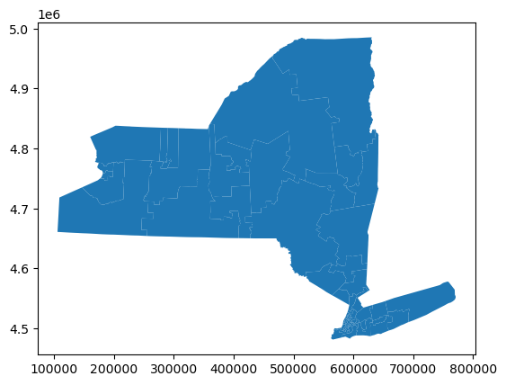

```python
#Plotting Data from Task 2
sen22.plot()
```

New Data

```python
#Import new Bureau of Land Management (BLM) public land data
States = geopandas.read_file('./Task3_data/PADUS3_0_State_CA_GeoJSON.zip', driver = 'zip')
CA = geopandas.read_file('./Task3_data/PADUS3_0Designation_StateCA.json', driver = 'json')
HI = geopandas.read_file('./Task3_data/PADUS3_0Designation_StateHI.json', driver = 'json')
```

```python
CA.head(5)
```

|  | FID | FeatClass | d_FeatClas | Category | d_Category | Own_Type | d_Own_Type | Own_Name | d_Own_Name | Loc_Own | ... | GAPCdDt | IUCN_Cat | d_IUCN_Cat | IUCNCtSrc | IUCNCtDt | Date_Est | Comments | SHAPE_Leng | SHAPE_Area | geometry |
| --- | --- | --- | --- | --- | --- | --- | --- | --- | --- | --- | --- | --- | --- | --- | --- | --- | --- | --- | --- | --- | --- |
| 0 | 0 | Designation | Designation | Designation | Designation | UNK | Unknown | UNK | Unknown | Unknown | ... | 2021 | Unassigned | Unassigned | GAP - Default | 2021 | 2003 |  | 9017.781811 | 2.613013e+06 | POLYGON ((-2140056.013 2008147.221, -2140059.8... |
| 1 | 1 | Designation | Designation | Designation | Designation | DIST | Regional Agency Special District | REG | Regional Agency Land | Isla Vista Recreation and Park District | ... | 2021 | Unassigned | Unassigned | GAP - Default | 2021 |  |  | 107.532839 | 7.208198e+02 | POLYGON ((-2152918.930 1532823.614, -2152920.0... |
| 2 | 2 | Designation | Designation | Designation | Designation | DIST | Regional Agency Special District | REG | Regional Agency Land | JURUPA COMMUNITY SERVICES DIST | ... | 2021 | Unassigned | Unassigned | GAP - Default | 2021 |  |  | 1167.149365 | 6.402195e+04 | POLYGON ((-1960670.169 1432720.950, -1960663.9... |
| 3 | 3 | Designation | Designation | Designation | Designation | DIST | Regional Agency Special District | REG | Regional Agency Land | MOUNTAINS RECREATION AND & CONSERVATION AUTHORITY | ... | 2021 | V | V: Protected landscape / seascape | GAP - Default | 2021 |  |  | 4599.444122 | 5.627679e+05 | POLYGON ((-2032117.449 1493975.578, -2032116.8... |
| 4 | 4 | Designation | Designation | Designation | Designation | DIST | Regional Agency Special District | REG | Regional Agency Land | Port of San Francisco | ... | 2021 | Unassigned | Unassigned | GAP - Default | 2021 |  |  | 405.280605 | 2.792601e+03 | POLYGON ((-2273446.935 1955092.645, -2273456.8... |

5 rows × 45 columns

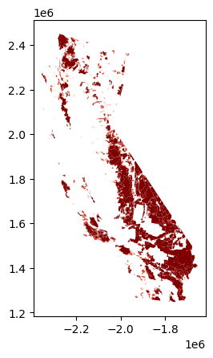

```python
#Plotting a Chloropeth Map
##Public Land Area in CA (Or>Rd)
CA.plot(column='SHAPE_Area', cmap='OrRd', scheme = 'quantiles')
```

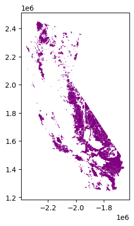

```python
#Check CRS
CA.plot(marker='*', color = 'purple', markersize = 5)
CA = CA.to_crs(States.crs)
```

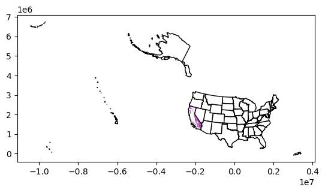

```python
#Map with Layers
base = States.plot(color = 'white', edgecolor = "black")
CA.plot(ax = base, color = 'purple')
```

```python
HI.head(2)
```

|  | FID | FeatClass | d_FeatClas | Category | d_Category | Own_Type | d_Own_Type | Own_Name | d_Own_Name | Loc_Own | ... | GAPCdDt | IUCN_Cat | d_IUCN_Cat | IUCNCtSrc | IUCNCtDt | Date_Est | Comments | SHAPE_Leng | SHAPE_Area | geometry |
| --- | --- | --- | --- | --- | --- | --- | --- | --- | --- | --- | --- | --- | --- | --- | --- | --- | --- | --- | --- | --- | --- |
| 0 | 0 | Designation | Designation | Designation | Designation | STAT | State | SDNR | State Department of Natural Resources | State Department of Natural Resources | ... | 2005 | Other Conservation Area | Other Conservation Area | GAP - Default | 2021 |  |  | 25489.993303 | 1.871497e+07 | POLYGON ((-6124501.919 1911932.022, -6124507.5... |
| 1 | 1 | Designation | Designation | Designation | Designation | STAT | State | SDNR | State Department of Natural Resources | State Department of Natural Resources | ... | 2005 | Other Conservation Area | Other Conservation Area | GAP - Default | 2021 |  |  | 15373.752480 | 4.615622e+06 | POLYGON ((-6125746.096 1899869.271, -6125748.5... |

2 rows × 45 columns

```python
#Interactive mapping
HI.explore(
    column = "SHAPE_Area",
    scheme = "quantiles",
    popup = True,
    tiles = "CartoDB positron",
    cmap = "OrRd"
)
```

Make this Notebook Trusted to load map: File -> Trust Notebook

[interactive chart not shown]

```python
CA.head(2)
```

|  | FID | FeatClass | d_FeatClas | Category | d_Category | Own_Type | d_Own_Type | Own_Name | d_Own_Name | Loc_Own | ... | GAPCdDt | IUCN_Cat | d_IUCN_Cat | IUCNCtSrc | IUCNCtDt | Date_Est | Comments | SHAPE_Leng | SHAPE_Area | geometry |
| --- | --- | --- | --- | --- | --- | --- | --- | --- | --- | --- | --- | --- | --- | --- | --- | --- | --- | --- | --- | --- | --- |
| 0 | 0 | Designation | Designation | Designation | Designation | UNK | Unknown | UNK | Unknown | Unknown | ... | 2021 | Unassigned | Unassigned | GAP - Default | 2021 | 2003 |  | 9017.781811 | 2.613013e+06 | POLYGON ((-2140056.013 2008147.221, -2140059.8... |
| 1 | 1 | Designation | Designation | Designation | Designation | DIST | Regional Agency Special District | REG | Regional Agency Land | Isla Vista Recreation and Park District | ... | 2021 | Unassigned | Unassigned | GAP - Default | 2021 |  |  | 107.532839 | 7.208198e+02 | POLYGON ((-2152918.930 1532823.614, -2152920.0... |

2 rows × 45 columns

## Notes

### (attempt at using plotly with csv and geojson files)

```python
#Install plotly and plotly express to geo_env environment
```

```python
%pip install plotly==5.13.1
%pip install "jupyterlab>=3" "ipywidgets>=7.6"
```

```python
#Import Forest Service (FS) Land Data
FS_data = geopandas.read_file('.\Task3_data\FS_National_Forests_Dataset_(US_Forest_Service_Proclaimed_Forests).geojson', driver = 'geojson')
```

```python
import pandas as pd
df = pd.read_csv('.\Task3_data\FS_National_Forests_Dataset_(US_Forest_Service_Proclaimed_Forests).csv')
```

```python
display(FS_data.head)
```

```
<bound method NDFrame.head of     PROCLAIMEDFORESTID                  FORESTNAME     GIS_ACRES  OBJECTID  \
0         295469010328   Deschutes National Forest  1.869821e+06    174463
1         262611010328      Winema National Forest  1.094251e+06    174464
2         106640010328     Fremont National Forest  1.713917e+06    174465
3         106887010328   Mt. Baker National Forest  1.317677e+06    174466
4         295464010328    Siskiyou National Forest  1.161683e+06    174467
..                 ...                         ...           ...       ...
149       295496010328       Routt National Forest  1.249143e+06    174612
150       295470010328    Nebraska National Forest  2.292148e+05    174613
151       295498010328  Rio Grande National Forest  1.937386e+06    174614
152       295370010328     Tongass National Forest  1.769951e+07    174615
153       295488010328     Kaniksu National Forest  1.951102e+06    174616

     SHAPEAREA    SHAPELEN                                           geometry
0     0.846780    9.144263  MULTIPOLYGON (((-121.55548 44.67565, -121.5558...
1     0.487341   14.553148  MULTIPOLYGON (((-121.96112 42.67550, -121.9611...
2     0.760518   11.282002  MULTIPOLYGON (((-120.52852 42.57091, -120.5332...
3     0.648567   10.659633  MULTIPOLYGON (((-121.75954 48.99733, -121.7645...
4     0.513886    6.987056  MULTIPOLYGON (((-124.18267 41.99818, -124.1804...
..         ...         ...                                                ...
149   0.537375   11.413221  MULTIPOLYGON (((-106.98483 41.00330, -106.9885...
150   0.101351    3.170945  MULTIPOLYGON (((-102.92053 42.80322, -102.9205...
151   0.801284   12.822779  MULTIPOLYGON (((-106.06221 38.37413, -106.0620...
152  10.607063  379.522086  MULTIPOLYGON (((-135.31972 59.22179, -135.3195...
153   0.958803   18.818140  MULTIPOLYGON (((-116.13427 48.68079, -116.1342...

[154 rows x 7 columns]>
```

```python
display(df.head)
```

```
<bound method NDFrame.head of      PROCLAIMEDFORESTID                  FORESTNAME     GIS_ACRES  OBJECTID  \
0          295469010328   Deschutes National Forest  1.869821e+06    174463
1          262611010328      Winema National Forest  1.094251e+06    174464
2          106640010328     Fremont National Forest  1.713917e+06    174465
3          106887010328   Mt. Baker National Forest  1.317677e+06    174466
4          295464010328    Siskiyou National Forest  1.161683e+06    174467
..                  ...                         ...           ...       ...
149        295496010328       Routt National Forest  1.249143e+06    174612
150        295470010328    Nebraska National Forest  2.292148e+05    174613
151        295498010328  Rio Grande National Forest  1.937386e+06    174614
152        295370010328     Tongass National Forest  1.769951e+07    174615
153        295488010328     Kaniksu National Forest  1.951102e+06    174616

     SHAPEAREA    SHAPELEN
0     0.846780    9.144263
1     0.487341   14.553148
2     0.760518   11.282002
3     0.648567   10.659633
4     0.513886    6.987056
..         ...         ...
149   0.537375   11.413221
150   0.101351    3.170945
151   0.801284   12.822779
152  10.607063  379.522086
153   0.958803   18.818140

[154 rows x 6 columns]>
```

```python
print(df["FORESTNAME"][2])
print(FS_data["FORESTNAME"][2])
```

```
Fremont National Forest
Fremont National Forest
```

```python
#plotly express...tried and failed
import plotly.express as px
FS_plotly = px.choropleth_mapbox(data_frame = df, geojson = FS_data, locations = 'FORESTNAME', color ='SHAPEAREA',
                                color_continuous_scale = 'tealrose',
                                mapbox_style = "carto-positron",
                                zoom = 3, center = {"lat":37.0902, "lon": -95.7129},
                                opacity = 0.5,
                                )
FS_plotly.show()
```